# Exploratory Data Analysis: a challenge on summarizing categorical variables

Exercise to lecture 9

Author

Aurélien Sallin

# Exercise

Use what we saw in the lecture to solve the following problem 💪. You have the following dataset:

```r
df_p <- data.frame(id = 1:5,
                   first_name = c("Anna", "John", "Claire", "Evan", "Brigitte"),
                   profession = c("Economist", "Data Scientist",
                                  "Data Scientist", "Economist", "Economist"),
                   salaryK = c("100 ", 120, 90, 110, 105),
                   experienceY = c(10, 10, 10, 10, 10))

df_p
```

```
  id first_name     profession salaryK experienceY
1  1       Anna      Economist    100           10
2  2       John Data Scientist     120          10
3  3     Claire Data Scientist      90          10
4  4       Evan      Economist     110          10
5  5   Brigitte      Economist     105          10
```

1. Clean the data
2. Summarize the data.
3. Give summary statistics on the categorical variable “profession”. What can you show, and how can you code it?
4. You are interested in quantifying the gender pay gap. Prepare the data accordingly and give an estimate of the gender pay gap.

Good luck! 🍀

# Solution

## Step 1: clean the data

We see that the salary variable is a character variable, and we need to convert it to a numeric variable. We also see that there are some extra spaces in the salary variable: these extra spaces are automatically removed when coercing to numeric with the function `as.numeric()`. However, we might want to use `trimws()` to be sure and remove leading and trailing white spaces .

```r
# Load dplyr and tidyr packages, which are all parts of tidyverse
library(tidyverse)

df_p <- df_p |>
  mutate(
    salaryK = as.numeric(trimws(salaryK)),  # Remove extra spaces and convert to numeric
  )

# Show cleaned data
df_p
```

```
  id first_name     profession salaryK experienceY
1  1       Anna      Economist     100          10
2  2       John Data Scientist     120          10
3  3     Claire Data Scientist      90          10
4  4       Evan      Economist     110          10
5  5   Brigitte      Economist     105          10
```

## Step 2: summarize the data

As seen in the lecture, we can use the `summary()` function to get a quick overview of the dataset. We can also use the `summarytools::dfSummary()` from `summarytools`.

The `dfSummary()` command provides a comprehensive summary of the dataset (dimensions, number of duplicates) and, for each variable, the distribution and a rudimentary graph with a histogram.

```r
# Summary statistics of the dataset
summary(df_p)
```

```
       id     first_name         profession           salaryK     experienceY
 Min.   :1   Length:5           Length:5           Min.   : 90   Min.   :10
 1st Qu.:2   Class :character   Class :character   1st Qu.:100   1st Qu.:10
 Median :3   Mode  :character   Mode  :character   Median :105   Median :10
 Mean   :3                                         Mean   :105   Mean   :10
 3rd Qu.:4                                         3rd Qu.:110   3rd Qu.:10
 Max.   :5                                         Max.   :120   Max.   :10
```

```r
# use summarytools
summarytools::dfSummary(df_p)
```

```
Data Frame Summary
df_p
Dimensions: 5 x 5
Duplicates: 0

------------------------------------------------------------------------------------------------------------
No   Variable      Stats / Values           Freqs (% of Valid)   Graph                  Valid      Missing
---- ------------- ------------------------ -------------------- ---------------------- ---------- ---------
1    id            Mean (sd) : 3 (1.6)      1 : 1 (20.0%)        IIII                   5          0
     [integer]     min < med < max:         2 : 1 (20.0%)        IIII                   (100.0%)   (0.0%)
                   1 < 3 < 5                3 : 1 (20.0%)        IIII
                   IQR (CV) : 2 (0.5)       4 : 1 (20.0%)        IIII
                                            5 : 1 (20.0%)        IIII

2    first_name    1. Anna                  1 (20.0%)            IIII                   5          0
     [character]   2. Brigitte              1 (20.0%)            IIII                   (100.0%)   (0.0%)
                   3. Claire                1 (20.0%)            IIII
                   4. Evan                  1 (20.0%)            IIII
                   5. John                  1 (20.0%)            IIII

3    profession    1. Data Scientist        2 (40.0%)            IIIIIIII               5          0
     [character]   2. Economist             3 (60.0%)            IIIIIIIIIIII           (100.0%)   (0.0%)

4    salaryK       Mean (sd) : 105 (11.2)   90 : 1 (20.0%)       IIII                   5          0
     [numeric]     min < med < max:         100 : 1 (20.0%)      IIII                   (100.0%)   (0.0%)
                   90 < 105 < 120           105 : 1 (20.0%)      IIII
                   IQR (CV) : 10 (0.1)      110 : 1 (20.0%)      IIII
                                            120 : 1 (20.0%)      IIII

5    experienceY   1 distinct value         10 : 5 (100.0%)      IIIIIIIIIIIIIIIIIIII   5          0
     [numeric]                                                                          (100.0%)   (0.0%)
------------------------------------------------------------------------------------------------------------
```

We might also want to check summary statistics per profession. We can use the `group_by()` and `summarize()` functions from the `dplyr` package.

```r
# Grouped summary
df_summary <- df_p |>
  group_by(profession) |>
  summarize(
    mean_salary = mean(salaryK, na.rm = TRUE),
    median_salary = median(salaryK, na.rm = TRUE),
    count = n()
  )

# Display the summary
df_summary
```

```
# A tibble: 2 × 4
  profession     mean_salary median_salary count
  <chr>                <dbl>         <dbl> <int>
1 Data Scientist         105           105     2
2 Economist              105           105     3
```

## Step 3: Summary statistics on the categorical variable “profession”

Statistics on a categorical variable are essentially frequency tables of the variable. It shows how many times each category appears in the dataset.

Here are some ways we can show the summary statistics for a categorical variable.

Finally, we can visualize the distribution of the profession variable using a bar plot.

```r
# Frequency table of the profession variable
table(df_p$profession)
```

```
Data Scientist      Economist
             2              3
```

```r
# Count of each profession
profession_summary <- df_p |>
  count(profession) |>
  mutate(percentage_profession = n / sum(n) * 100)

# Display the summary
profession_summary
```

```
      profession n percentage_profession
1 Data Scientist 2                    40
2      Economist 3                    60
```

```r
# Use summarytools
summarytools::freq(df_p$profession)
```

```
Frequencies
df_p$profession
Type: Character

                       Freq   % Valid   % Valid Cum.   % Total   % Total Cum.
-------------------- ------ --------- -------------- --------- --------------
      Data Scientist      2     40.00          40.00     40.00          40.00
           Economist      3     60.00         100.00     60.00         100.00
                <NA>      0                               0.00         100.00
               Total      5    100.00         100.00    100.00         100.00
```

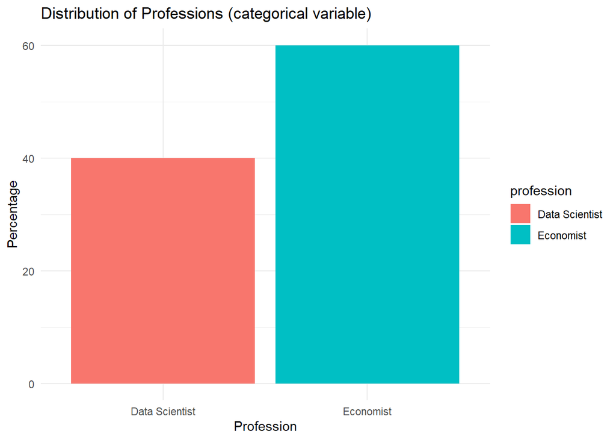

```r
# Visualize the distribution
library(ggplot2)
ggplot(profession_summary, aes(x = profession, y = percentage_profession, fill = profession)) +
  geom_bar(stat = "identity") +
  labs(
    title = "Distribution of Professions (categorical variable)",
    x = "Profession",
    y = "Percentage"
  ) +
  theme_minimal()
```

## Step 4: Estimate the Gender Pay Gap

To estimate the gender pay gap, we need to create a variable that indicates the gender. We create this variable using the names and the function `case_when()` in `mutate`. We can then calculate the mean salary per gender category.

```r
# Create the gender variable with case_when
df_p <- df_p |>
  mutate(
    gender = case_when(  # Add a gender variable based on first names
      first_name %in% c("Anna", "Claire", "Brigitte") ~ "Female",
      first_name %in% c("John", "Evan") ~ "Male",
      TRUE ~ "Unknown"
    )
  )

# Group by gender and calculate mean salary
gender_summary <- df_p |>
  group_by(gender) |>
  summarize(
    mean_salary = mean(salaryK, na.rm = TRUE),
  )

gender_summary
```

```
# A tibble: 2 × 2
  gender mean_salary
  <chr>        <dbl>
1 Female        98.3
2 Male         115
```

```r
# Calculate pay gap using a filter function within summarize
pay_gap <- gender_summary |>
  summarize(
    gap_percentage = (mean_salary[gender == "Male"] - mean_salary[gender == "Female"]) /
                     mean_salary[gender == "Male"] * 100
  )

# OR: pivot the summary table and use mutate
gender_summary |>
  pivot_wider(
    names_from = gender,
    values_from = mean_salary,
    names_prefix = "salary"
    ) |>
  mutate(gap = (salaryMale - salaryFemale) / salaryMale * 100)
```

```
# A tibble: 1 × 3
  salaryFemale salaryMale   gap
         <dbl>      <dbl> <dbl>
1         98.3        115  14.5
```

```r
# Display the gender pay gap
pay_gap
```

```
# A tibble: 1 × 1
  gap_percentage
           <dbl>
1           14.5
```

We see that **the gender pay gap is 14.5%** in this very simplistic example.